# Rules

1. You may choose no more than one rider from Pot A, and no more than one rider from Pot B. You can pick as many riders as you wish that are not in A or B.
2. If two contestants submit teams with identical riders the contestant to submit last of the two will be asked to substitute one rider (to avoid identical teams). The contestant can chose any alternative rider provided: 1) the team of 8 maintains no more than 1 rider from each of Pot A & Pot B; 2) the team is different from all other submissions by at least 1 rider.
3. If after Stage 1 a contestant discovers that one or more of their riders did not start due to substitutions by the ProTeams they will have a single chance to make replacements. This must be completed before the start of Stage 2 and must comply with the constraints set out in 2) above. In addition, any added rider(s) must not have finished higher then the contestants riders 1 / 2 / 3 in stage 1 - i.e. if contestant A has only 7 riders after Stage 1 because of a DNS and their top 3 riders finish in positions 5, 11 & 19 they may select a replacement rider but only one out of the field that finished below 19th place on Stage 1.
4. Positions on the stage will be decided by ranking of combined times for each team with the lowest combined time winning. Combined time for each team is calculated as the sum of the times for the top 3 riders from the team (no Bonuses or Penalties). In the event of tied times the tiebreakers will be the lowest rank of the top 3 riders, followed by the lowest rank of all 8 riders.
5. There will be a separate points competition in the spirit of the “green” jersey. For the Green Jersey Points Competiton the winner of the stage is calculated by summing the green jersey points for all 8 riders on each team. The team with the highest points wins the stage.The points will be awarded according to the official TDF green jersey competition allocations (see table below) which awards higher for sprint stages.

$~$

$~$

**Pot A**

POGAČAR Tadej  
VINGEGAARD Jonas  
DEL TORO Isaac  
EVENEPOEL Remco  
PIDCOCK Tom  
GALL Felix  
PHILIPSEN Jasper  
SEIXAS Paul  
VAN DER POEL Mathieu  
DE LIE Arnaud

$~$

**Pot B**

VAN AERT Wout  
LIPOWITZ Florian  
SCHMID Mauro  
MAGNIER Paul  
LUND ANDERSEN Tobias  
GREGOIRE Romain  
SCARONI Christian  
PEDERSEN Mads  
HINDLEY Jai  
JOHANNESSEN Tobias

$~$

$~$

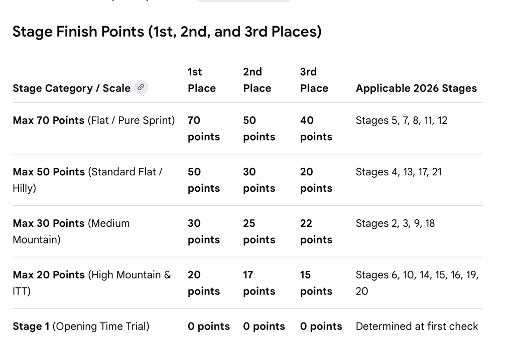